# Risk Factor Analysis

## Outcome Variable

**Outcome Variable:** ever_stunted

## Predictor Variables

**Intervention Variable:** brthmon

**Adjustment Set:**

unadjusted

## Stratifying Variables

The analysis was stratified on these variable(s):

- agecat
- studyid
- country

## Data Summary

| agecat | studyid | country | brthmon | ever_stunted | n_cell | n |
| --- | --- | --- | --- | --- | --- | --- |
| 0-6 months | ki0047075b-MAL-ED | BANGLADESH | 1 | 0 | 17 | 265 |
| 0-6 months | ki0047075b-MAL-ED | BANGLADESH | 1 | 1 | 4 | 265 |
| 0-6 months | ki0047075b-MAL-ED | BANGLADESH | 2 | 0 | 19 | 265 |
| 0-6 months | ki0047075b-MAL-ED | BANGLADESH | 2 | 1 | 6 | 265 |
| 0-6 months | ki0047075b-MAL-ED | BANGLADESH | 3 | 0 | 18 | 265 |
| 0-6 months | ki0047075b-MAL-ED | BANGLADESH | 3 | 1 | 7 | 265 |
| 0-6 months | ki0047075b-MAL-ED | BANGLADESH | 4 | 0 | 22 | 265 |
| 0-6 months | ki0047075b-MAL-ED | BANGLADESH | 4 | 1 | 0 | 265 |
| 0-6 months | ki0047075b-MAL-ED | BANGLADESH | 5 | 0 | 17 | 265 |
| 0-6 months | ki0047075b-MAL-ED | BANGLADESH | 5 | 1 | 5 | 265 |
| 0-6 months | ki0047075b-MAL-ED | BANGLADESH | 6 | 0 | 7 | 265 |
| 0-6 months | ki0047075b-MAL-ED | BANGLADESH | 6 | 1 | 4 | 265 |
| 0-6 months | ki0047075b-MAL-ED | BANGLADESH | 7 | 0 | 15 | 265 |
| 0-6 months | ki0047075b-MAL-ED | BANGLADESH | 7 | 1 | 5 | 265 |
| 0-6 months | ki0047075b-MAL-ED | BANGLADESH | 8 | 0 | 21 | 265 |
| 0-6 months | ki0047075b-MAL-ED | BANGLADESH | 8 | 1 | 5 | 265 |
| 0-6 months | ki0047075b-MAL-ED | BANGLADESH | 9 | 0 | 20 | 265 |
| 0-6 months | ki0047075b-MAL-ED | BANGLADESH | 9 | 1 | 3 | 265 |
| 0-6 months | ki0047075b-MAL-ED | BANGLADESH | 10 | 0 | 20 | 265 |
| 0-6 months | ki0047075b-MAL-ED | BANGLADESH | 10 | 1 | 5 | 265 |
| 0-6 months | ki0047075b-MAL-ED | BANGLADESH | 11 | 0 | 15 | 265 |
| 0-6 months | ki0047075b-MAL-ED | BANGLADESH | 11 | 1 | 2 | 265 |
| 0-6 months | ki0047075b-MAL-ED | BANGLADESH | 12 | 0 | 26 | 265 |
| 0-6 months | ki0047075b-MAL-ED | BANGLADESH | 12 | 1 | 2 | 265 |
| 0-6 months | ki0047075b-MAL-ED | BRAZIL | 1 | 0 | 14 | 233 |
| 0-6 months | ki0047075b-MAL-ED | BRAZIL | 1 | 1 | 1 | 233 |
| 0-6 months | ki0047075b-MAL-ED | BRAZIL | 2 | 0 | 23 | 233 |
| 0-6 months | ki0047075b-MAL-ED | BRAZIL | 2 | 1 | 2 | 233 |
| 0-6 months | ki0047075b-MAL-ED | BRAZIL | 3 | 0 | 18 | 233 |
| 0-6 months | ki0047075b-MAL-ED | BRAZIL | 3 | 1 | 2 | 233 |

[output cut: 1936 more lines]

The following strata were considered:

- agecat: 0-24 months, studyid: ki0047075b-MAL-ED, country: BANGLADESH
- agecat: 0-24 months, studyid: ki0047075b-MAL-ED, country: BRAZIL
- agecat: 0-24 months, studyid: ki0047075b-MAL-ED, country: INDIA
- agecat: 0-24 months, studyid: ki0047075b-MAL-ED, country: NEPAL
- agecat: 0-24 months, studyid: ki0047075b-MAL-ED, country: PERU
- agecat: 0-24 months, studyid: ki0047075b-MAL-ED, country: SOUTH AFRICA
- agecat: 0-24 months, studyid: ki0047075b-MAL-ED, country: TANZANIA, UNITED REPUBLIC OF
- agecat: 0-24 months, studyid: ki1000108-CMC-V-BCS-2002, country: INDIA
- agecat: 0-24 months, studyid: ki1000108-IRC, country: INDIA
- agecat: 0-24 months, studyid: ki1000109-EE, country: PAKISTAN
- agecat: 0-24 months, studyid: ki1000109-ResPak, country: PAKISTAN
- agecat: 0-24 months, studyid: ki1000304b-SAS-CompFeed, country: INDIA
- agecat: 0-24 months, studyid: ki1000304b-SAS-FoodSuppl, country: INDIA
- agecat: 0-24 months, studyid: ki1017093-NIH-Birth, country: BANGLADESH
- agecat: 0-24 months, studyid: ki1066203-TanzaniaChild2, country: TANZANIA, UNITED REPUBLIC OF
- agecat: 0-24 months, studyid: ki1101329-Keneba, country: GAMBIA
- agecat: 0-24 months, studyid: ki1112895-Guatemala BSC, country: GUATEMALA
- agecat: 0-24 months, studyid: ki1112895-iLiNS-Zinc, country: BURKINA FASO
- agecat: 0-24 months, studyid: ki1113344-GMS-Nepal, country: NEPAL
- agecat: 0-24 months, studyid: ki1114097-CMIN, country: BANGLADESH
- agecat: 0-24 months, studyid: ki1114097-CMIN, country: BRAZIL
- agecat: 0-24 months, studyid: ki1114097-CMIN, country: GUINEA-BISSAU
- agecat: 0-24 months, studyid: ki1114097-CMIN, country: PERU
- agecat: 0-24 months, studyid: ki1114097-CONTENT, country: PERU
- agecat: 0-24 months, studyid: ki1119695-PROBIT, country: BELARUS
- agecat: 0-24 months, studyid: ki1126311-ZVITAMBO, country: ZIMBABWE
- agecat: 0-24 months, studyid: ki1148112-LCNI-5, country: MALAWI
- agecat: 0-24 months, studyid: kiGH5241-JiVitA-3, country: BANGLADESH
- agecat: 0-24 months, studyid: kiGH5241-JiVitA-4, country: BANGLADESH
- agecat: 0-6 months, studyid: ki0047075b-MAL-ED, country: BANGLADESH
- agecat: 0-6 months, studyid: ki0047075b-MAL-ED, country: BRAZIL
- agecat: 0-6 months, studyid: ki0047075b-MAL-ED, country: INDIA
- agecat: 0-6 months, studyid: ki0047075b-MAL-ED, country: NEPAL
- agecat: 0-6 months, studyid: ki0047075b-MAL-ED, country: PERU
- agecat: 0-6 months, studyid: ki0047075b-MAL-ED, country: SOUTH AFRICA
- agecat: 0-6 months, studyid: ki0047075b-MAL-ED, country: TANZANIA, UNITED REPUBLIC OF
- agecat: 0-6 months, studyid: ki1000108-CMC-V-BCS-2002, country: INDIA
- agecat: 0-6 months, studyid: ki1000108-IRC, country: INDIA
- agecat: 0-6 months, studyid: ki1000109-EE, country: PAKISTAN
- agecat: 0-6 months, studyid: ki1000109-ResPak, country: PAKISTAN
- agecat: 0-6 months, studyid: ki1000304b-SAS-CompFeed, country: INDIA
- agecat: 0-6 months, studyid: ki1000304b-SAS-FoodSuppl, country: INDIA
- agecat: 0-6 months, studyid: ki1017093-NIH-Birth, country: BANGLADESH
- agecat: 0-6 months, studyid: ki1066203-TanzaniaChild2, country: TANZANIA, UNITED REPUBLIC OF
- agecat: 0-6 months, studyid: ki1101329-Keneba, country: GAMBIA
- agecat: 0-6 months, studyid: ki1112895-Guatemala BSC, country: GUATEMALA
- agecat: 0-6 months, studyid: ki1113344-GMS-Nepal, country: NEPAL
- agecat: 0-6 months, studyid: ki1114097-CMIN, country: BANGLADESH
- agecat: 0-6 months, studyid: ki1114097-CMIN, country: BRAZIL
- agecat: 0-6 months, studyid: ki1114097-CMIN, country: GUINEA-BISSAU
- agecat: 0-6 months, studyid: ki1114097-CMIN, country: PERU
- agecat: 0-6 months, studyid: ki1114097-CONTENT, country: PERU
- agecat: 0-6 months, studyid: ki1119695-PROBIT, country: BELARUS
- agecat: 0-6 months, studyid: ki1126311-ZVITAMBO, country: ZIMBABWE
- agecat: 0-6 months, studyid: ki1148112-LCNI-5, country: MALAWI
- agecat: 0-6 months, studyid: kiGH5241-JiVitA-3, country: BANGLADESH
- agecat: 0-6 months, studyid: kiGH5241-JiVitA-4, country: BANGLADESH
- agecat: 6-24 months, studyid: ki0047075b-MAL-ED, country: BANGLADESH
- agecat: 6-24 months, studyid: ki0047075b-MAL-ED, country: BRAZIL
- agecat: 6-24 months, studyid: ki0047075b-MAL-ED, country: INDIA
- agecat: 6-24 months, studyid: ki0047075b-MAL-ED, country: NEPAL
- agecat: 6-24 months, studyid: ki0047075b-MAL-ED, country: PERU
- agecat: 6-24 months, studyid: ki0047075b-MAL-ED, country: SOUTH AFRICA
- agecat: 6-24 months, studyid: ki0047075b-MAL-ED, country: TANZANIA, UNITED REPUBLIC OF
- agecat: 6-24 months, studyid: ki1000108-CMC-V-BCS-2002, country: INDIA
- agecat: 6-24 months, studyid: ki1000108-IRC, country: INDIA
- agecat: 6-24 months, studyid: ki1000109-EE, country: PAKISTAN
- agecat: 6-24 months, studyid: ki1000109-ResPak, country: PAKISTAN
- agecat: 6-24 months, studyid: ki1000304b-SAS-CompFeed, country: INDIA
- agecat: 6-24 months, studyid: ki1000304b-SAS-FoodSuppl, country: INDIA
- agecat: 6-24 months, studyid: ki1017093-NIH-Birth, country: BANGLADESH
- agecat: 6-24 months, studyid: ki1066203-TanzaniaChild2, country: TANZANIA, UNITED REPUBLIC OF
- agecat: 6-24 months, studyid: ki1101329-Keneba, country: GAMBIA
- agecat: 6-24 months, studyid: ki1112895-Guatemala BSC, country: GUATEMALA
- agecat: 6-24 months, studyid: ki1112895-iLiNS-Zinc, country: BURKINA FASO
- agecat: 6-24 months, studyid: ki1113344-GMS-Nepal, country: NEPAL
- agecat: 6-24 months, studyid: ki1114097-CMIN, country: BANGLADESH
- agecat: 6-24 months, studyid: ki1114097-CMIN, country: BRAZIL
- agecat: 6-24 months, studyid: ki1114097-CMIN, country: GUINEA-BISSAU
- agecat: 6-24 months, studyid: ki1114097-CMIN, country: PERU
- agecat: 6-24 months, studyid: ki1114097-CONTENT, country: PERU
- agecat: 6-24 months, studyid: ki1119695-PROBIT, country: BELARUS
- agecat: 6-24 months, studyid: ki1126311-ZVITAMBO, country: ZIMBABWE
- agecat: 6-24 months, studyid: ki1148112-LCNI-5, country: MALAWI
- agecat: 6-24 months, studyid: kiGH5241-JiVitA-3, country: BANGLADESH
- agecat: 6-24 months, studyid: kiGH5241-JiVitA-4, country: BANGLADESH

### Dropped Strata

Some strata were dropped due to rare outcomes:

- agecat: 0-6 months, studyid: ki0047075b-MAL-ED, country: BANGLADESH
- agecat: 0-6 months, studyid: ki0047075b-MAL-ED, country: BRAZIL
- agecat: 0-6 months, studyid: ki0047075b-MAL-ED, country: INDIA
- agecat: 0-6 months, studyid: ki0047075b-MAL-ED, country: NEPAL
- agecat: 0-6 months, studyid: ki0047075b-MAL-ED, country: PERU
- agecat: 0-6 months, studyid: ki0047075b-MAL-ED, country: SOUTH AFRICA
- agecat: 0-6 months, studyid: ki0047075b-MAL-ED, country: TANZANIA, UNITED REPUBLIC OF
- agecat: 0-6 months, studyid: ki1000108-CMC-V-BCS-2002, country: INDIA
- agecat: 0-6 months, studyid: ki1000108-IRC, country: INDIA
- agecat: 0-6 months, studyid: ki1000109-EE, country: PAKISTAN
- agecat: 0-6 months, studyid: ki1000109-ResPak, country: PAKISTAN
- agecat: 0-6 months, studyid: ki1000304b-SAS-FoodSuppl, country: INDIA
- agecat: 0-6 months, studyid: ki1017093-NIH-Birth, country: BANGLADESH
- agecat: 0-6 months, studyid: ki1112895-Guatemala BSC, country: GUATEMALA
- agecat: 0-6 months, studyid: ki1113344-GMS-Nepal, country: NEPAL
- agecat: 0-6 months, studyid: ki1114097-CMIN, country: BANGLADESH
- agecat: 0-6 months, studyid: ki1114097-CMIN, country: BRAZIL
- agecat: 0-6 months, studyid: ki1114097-CMIN, country: GUINEA-BISSAU
- agecat: 0-6 months, studyid: ki1114097-CMIN, country: PERU
- agecat: 0-6 months, studyid: ki1114097-CONTENT, country: PERU
- agecat: 0-6 months, studyid: ki1148112-LCNI-5, country: MALAWI
- agecat: 6-24 months, studyid: ki0047075b-MAL-ED, country: BANGLADESH
- agecat: 6-24 months, studyid: ki0047075b-MAL-ED, country: BRAZIL
- agecat: 6-24 months, studyid: ki0047075b-MAL-ED, country: INDIA
- agecat: 6-24 months, studyid: ki0047075b-MAL-ED, country: NEPAL
- agecat: 6-24 months, studyid: ki0047075b-MAL-ED, country: PERU
- agecat: 6-24 months, studyid: ki0047075b-MAL-ED, country: SOUTH AFRICA
- agecat: 6-24 months, studyid: ki0047075b-MAL-ED, country: TANZANIA, UNITED REPUBLIC OF
- agecat: 6-24 months, studyid: ki1000108-CMC-V-BCS-2002, country: INDIA
- agecat: 6-24 months, studyid: ki1000108-IRC, country: INDIA
- agecat: 6-24 months, studyid: ki1000109-EE, country: PAKISTAN
- agecat: 6-24 months, studyid: ki1000109-ResPak, country: PAKISTAN
- agecat: 6-24 months, studyid: ki1000304b-SAS-FoodSuppl, country: INDIA
- agecat: 6-24 months, studyid: ki1112895-Guatemala BSC, country: GUATEMALA
- agecat: 6-24 months, studyid: ki1114097-CMIN, country: BANGLADESH
- agecat: 6-24 months, studyid: ki1114097-CMIN, country: BRAZIL
- agecat: 6-24 months, studyid: ki1114097-CONTENT, country: PERU
- agecat: 6-24 months, studyid: ki1148112-LCNI-5, country: MALAWI
- agecat: 0-24 months, studyid: ki0047075b-MAL-ED, country: BRAZIL
- agecat: 0-24 months, studyid: ki0047075b-MAL-ED, country: INDIA
- agecat: 0-24 months, studyid: ki0047075b-MAL-ED, country: NEPAL
- agecat: 0-24 months, studyid: ki0047075b-MAL-ED, country: SOUTH AFRICA
- agecat: 0-24 months, studyid: ki0047075b-MAL-ED, country: TANZANIA, UNITED REPUBLIC OF
- agecat: 0-24 months, studyid: ki1000108-CMC-V-BCS-2002, country: INDIA
- agecat: 0-24 months, studyid: ki1000109-EE, country: PAKISTAN
- agecat: 0-24 months, studyid: ki1000109-ResPak, country: PAKISTAN
- agecat: 0-24 months, studyid: ki1000304b-SAS-FoodSuppl, country: INDIA
- agecat: 0-24 months, studyid: ki1113344-GMS-Nepal, country: NEPAL
- agecat: 0-24 months, studyid: ki1114097-CMIN, country: BANGLADESH
- agecat: 0-24 months, studyid: ki1114097-CMIN, country: BRAZIL
- agecat: 0-24 months, studyid: ki1114097-CONTENT, country: PERU

## Methods Detail

We’re interested in the causal parameters $E[Y_a]$ for all values of $a \in \mathcal{A}$. These parameters represent the mean outcome if, possibly contrary to fact, we intervened to set all units to have $A=a$. Under the randomization and positivity assumptions, these are identified by the statistical parameters $\psi_a=E_W[E_{Y|A,W}(Y|A=a,W)]$. In addition, we’re interested in the mean of $Y$, $E[Y]$ under no intervention (the observed mean). We will estimate these parameters by using SuperLearner to fit the relevant likelihood factors – $E_{Y|A,W}(Y|A=a,W)$ and $p(A=a|W)$, and then updating our likelihood fit using a joint TMLE.

For unadjusted analyses ($W=\{\}$), initial likelihoods were estimated using Lrnr_glm to estimate the simple $E(Y|A)$ and Lrnr_mean to estimate $p(A)$. For adjusted analyses, a small library containing Lrnr_glmnet, Lrnr_xgboost, and Lrnr_mean was used.

Having estimated these parameters, we will then use the delta method to estimate relative risks and attributable risks relative to a prespecified baseline level of $A$.

# Results Detail

## Results Plots

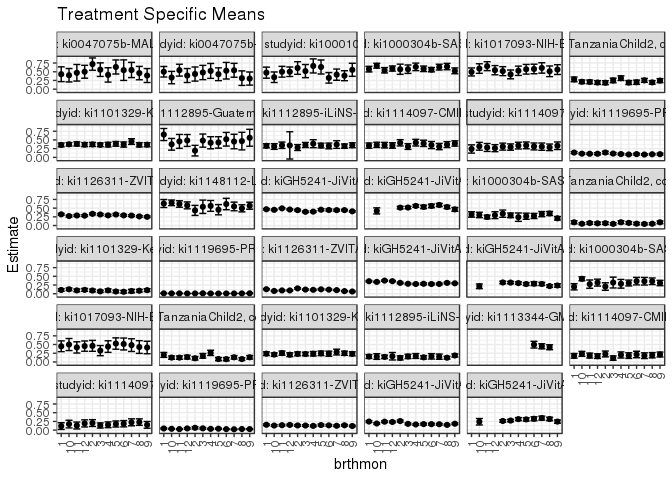

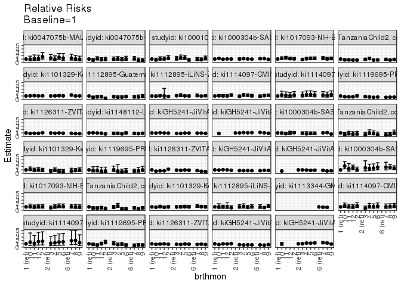

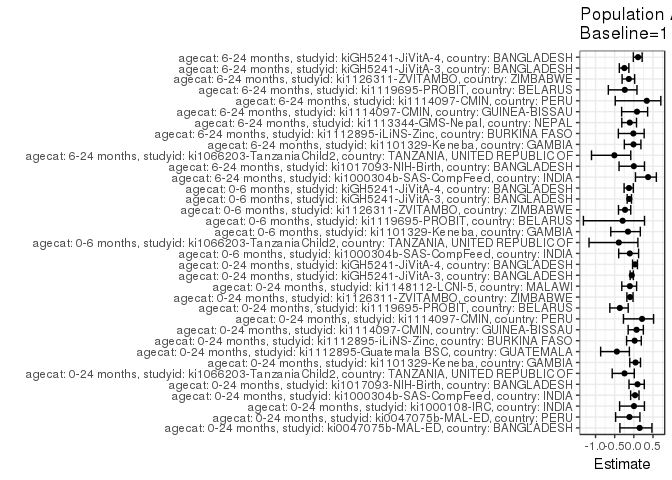

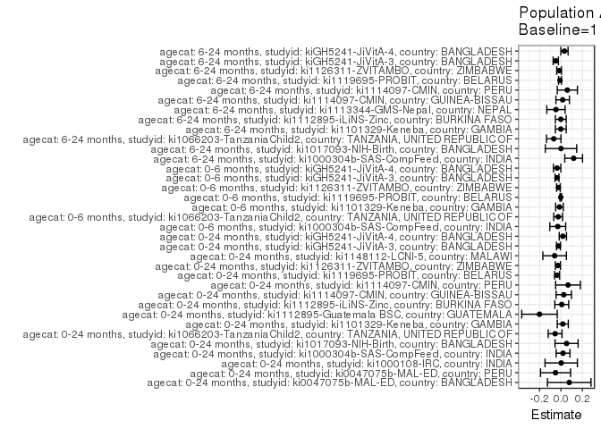

## Results Table

### Parameter: TSM

| agecat | studyid | country | intervention_level | baseline_level | estimate | ci_lower | ci_upper |
| --- | --- | --- | --- | --- | --- | --- | --- |
| 0-24 months | ki0047075b-MAL-ED | BANGLADESH | 1 | NA | 0.4285714 | 0.2165147 | 0.6406281 |
| 0-24 months | ki0047075b-MAL-ED | BANGLADESH | 2 | NA | 0.7200000 | 0.5436626 | 0.8963374 |
| 0-24 months | ki0047075b-MAL-ED | BANGLADESH | 3 | NA | 0.5600000 | 0.3650517 | 0.7549483 |
| 0-24 months | ki0047075b-MAL-ED | BANGLADESH | 4 | NA | 0.4090909 | 0.2032518 | 0.6149301 |
| 0-24 months | ki0047075b-MAL-ED | BANGLADESH | 5 | NA | 0.6363636 | 0.4349708 | 0.8377565 |
| 0-24 months | ki0047075b-MAL-ED | BANGLADESH | 6 | NA | 0.5454545 | 0.2506456 | 0.8402635 |
| 0-24 months | ki0047075b-MAL-ED | BANGLADESH | 7 | NA | 0.5500000 | 0.3315552 | 0.7684448 |
| 0-24 months | ki0047075b-MAL-ED | BANGLADESH | 8 | NA | 0.4615385 | 0.2695551 | 0.6535219 |
| 0-24 months | ki0047075b-MAL-ED | BANGLADESH | 9 | NA | 0.3913043 | 0.1914735 | 0.5911352 |
| 0-24 months | ki0047075b-MAL-ED | BANGLADESH | 10 | NA | 0.4000000 | 0.2076002 | 0.5923998 |
| 0-24 months | ki0047075b-MAL-ED | BANGLADESH | 11 | NA | 0.4705882 | 0.2328703 | 0.7083062 |
| 0-24 months | ki0047075b-MAL-ED | BANGLADESH | 12 | NA | 0.5000000 | 0.3144504 | 0.6855496 |
| 0-24 months | ki0047075b-MAL-ED | PERU | 1 | NA | 0.5000000 | 0.3485353 | 0.6514647 |
| 0-24 months | ki0047075b-MAL-ED | PERU | 2 | NA | 0.4347826 | 0.2318528 | 0.6377124 |
| 0-24 months | ki0047075b-MAL-ED | PERU | 3 | NA | 0.4782609 | 0.2737760 | 0.6827457 |
| 0-24 months | ki0047075b-MAL-ED | PERU | 4 | NA | 0.5238095 | 0.3098492 | 0.7377699 |
| 0-24 months | ki0047075b-MAL-ED | PERU | 5 | NA | 0.4285714 | 0.2449685 | 0.6121743 |
| 0-24 months | ki0047075b-MAL-ED | PERU | 6 | NA | 0.5294118 | 0.2917503 | 0.7670732 |
| 0-24 months | ki0047075b-MAL-ED | PERU | 7 | NA | 0.5416667 | 0.3419947 | 0.7413386 |
| 0-24 months | ki0047075b-MAL-ED | PERU | 8 | NA | 0.3157895 | 0.1064347 | 0.5251442 |
| 0-24 months | ki0047075b-MAL-ED | PERU | 9 | NA | 0.3043478 | 0.1159902 | 0.4927054 |
| 0-24 months | ki0047075b-MAL-ED | PERU | 10 | NA | 0.3333333 | 0.1552276 | 0.5114390 |
| 0-24 months | ki0047075b-MAL-ED | PERU | 11 | NA | 0.5454545 | 0.3752869 | 0.7156222 |
| 0-24 months | ki0047075b-MAL-ED | PERU | 12 | NA | 0.3913043 | 0.1915209 | 0.5910878 |
| 0-24 months | ki1000108-IRC | INDIA | 1 | NA | 0.4736842 | 0.3147365 | 0.6326319 |
| 0-24 months | ki1000108-IRC | INDIA | 2 | NA | 0.6071429 | 0.4260246 | 0.7882611 |
| 0-24 months | ki1000108-IRC | INDIA | 3 | NA | 0.5185185 | 0.3298200 | 0.7072170 |
| 0-24 months | ki1000108-IRC | INDIA | 4 | NA | 0.6666667 | 0.4648010 | 0.8685323 |
| 0-24 months | ki1000108-IRC | INDIA | 5 | NA | 0.6363636 | 0.4351055 | 0.8376217 |
| 0-24 months | ki1000108-IRC | INDIA | 6 | NA | 0.3243243 | 0.1733036 | 0.4753450 |

[output cut: 372 more lines]

### Parameter: E(Y)

| agecat | studyid | country | intervention_level | baseline_level | estimate | ci_lower | ci_upper |
| --- | --- | --- | --- | --- | --- | --- | --- |
| 0-24 months | ki0047075b-MAL-ED | BANGLADESH | NA | NA | 0.5056604 | 0.4453505 | 0.5659702 |
| 0-24 months | ki0047075b-MAL-ED | PERU | NA | NA | 0.4488449 | 0.3927492 | 0.5049406 |
| 0-24 months | ki1000108-IRC | INDIA | NA | NA | 0.4756098 | 0.4272105 | 0.5240091 |
| 0-24 months | ki1000304b-SAS-CompFeed | INDIA | NA | NA | 0.5942596 | 0.5539147 | 0.6346046 |
| 0-24 months | ki1017093-NIH-Birth | BANGLADESH | NA | NA | 0.5453100 | 0.5063654 | 0.5842547 |
| 0-24 months | ki1066203-TanzaniaChild2 | TANZANIA, UNITED REPUBLIC OF | NA | NA | 0.2257930 | 0.2090482 | 0.2425378 |
| 0-24 months | ki1101329-Keneba | GAMBIA | NA | NA | 0.3725557 | 0.3550013 | 0.3901102 |
| 0-24 months | ki1112895-Guatemala BSC | GUATEMALA | NA | NA | 0.4539683 | 0.3988995 | 0.5090370 |
| 0-24 months | ki1112895-iLiNS-Zinc | BURKINA FASO | NA | NA | 0.3384380 | 0.2882099 | 0.3886661 |
| 0-24 months | ki1114097-CMIN | GUINEA-BISSAU | NA | NA | 0.3636364 | 0.3393411 | 0.3879316 |
| 0-24 months | ki1114097-CMIN | PERU | NA | NA | 0.3057051 | 0.2760637 | 0.3353464 |
| 0-24 months | ki1119695-PROBIT | BELARUS | NA | NA | 0.1006096 | 0.0848963 | 0.1163228 |
| 0-24 months | ki1126311-ZVITAMBO | ZIMBABWE | NA | NA | 0.2926171 | 0.2851000 | 0.3001341 |
| 0-24 months | ki1148112-LCNI-5 | MALAWI | NA | NA | 0.5726190 | 0.5391450 | 0.6060930 |
| 0-24 months | kiGH5241-JiVitA-3 | BANGLADESH | NA | NA | 0.4437509 | 0.4362402 | 0.4512616 |
| 0-24 months | kiGH5241-JiVitA-4 | BANGLADESH | NA | NA | 0.5316060 | 0.5154292 | 0.5477829 |
| 0-6 months | ki1000304b-SAS-CompFeed | INDIA | NA | NA | 0.2882353 | 0.2618269 | 0.3146436 |
| 0-6 months | ki1066203-TanzaniaChild2 | TANZANIA, UNITED REPUBLIC OF | NA | NA | 0.0671953 | 0.0571686 | 0.0772221 |
| 0-6 months | ki1101329-Keneba | GAMBIA | NA | NA | 0.0937120 | 0.0822051 | 0.1052189 |
| 0-6 months | ki1119695-PROBIT | BELARUS | NA | NA | 0.0090570 | 0.0059070 | 0.0122070 |
| 0-6 months | ki1126311-ZVITAMBO | ZIMBABWE | NA | NA | 0.1052594 | 0.1001850 | 0.1103339 |
| 0-6 months | kiGH5241-JiVitA-3 | BANGLADESH | NA | NA | 0.3218623 | 0.3151120 | 0.3286127 |
| 0-6 months | kiGH5241-JiVitA-4 | BANGLADESH | NA | NA | 0.2867446 | 0.2729319 | 0.3005573 |
| 6-24 months | ki1000304b-SAS-CompFeed | INDIA | NA | NA | 0.3184647 | 0.2882909 | 0.3486385 |
| 6-24 months | ki1017093-NIH-Birth | BANGLADESH | NA | NA | 0.4500000 | 0.4023647 | 0.4976353 |
| 6-24 months | ki1066203-TanzaniaChild2 | TANZANIA, UNITED REPUBLIC OF | NA | NA | 0.1337304 | 0.1182039 | 0.1492569 |
| 6-24 months | ki1101329-Keneba | GAMBIA | NA | NA | 0.2347497 | 0.2177073 | 0.2517920 |
| 6-24 months | ki1112895-iLiNS-Zinc | BURKINA FASO | NA | NA | 0.1527830 | 0.1267871 | 0.1787788 |
| 6-24 months | ki1113344-GMS-Nepal | NEPAL | NA | NA | 0.4479167 | 0.4033837 | 0.4924496 |
| 6-24 months | ki1114097-CMIN | GUINEA-BISSAU | NA | NA | 0.1901352 | 0.1684337 | 0.2118368 |
| 6-24 months | ki1114097-CMIN | PERU | NA | NA | 0.1755319 | 0.1483241 | 0.2027397 |
| 6-24 months | ki1119695-PROBIT | BELARUS | NA | NA | 0.0380298 | 0.0285924 | 0.0474672 |
| 6-24 months | ki1126311-ZVITAMBO | ZIMBABWE | NA | NA | 0.1359880 | 0.1290274 | 0.1429485 |
| 6-24 months | kiGH5241-JiVitA-3 | BANGLADESH | NA | NA | 0.1970836 | 0.1890247 | 0.2051424 |
| 6-24 months | kiGH5241-JiVitA-4 | BANGLADESH | NA | NA | 0.2949907 | 0.2786334 | 0.3113480 |

### Parameter: RR

| agecat | studyid | country | intervention_level | baseline_level | estimate | ci_lower | ci_upper |
| --- | --- | --- | --- | --- | --- | --- | --- |
| 0-24 months | ki0047075b-MAL-ED | BANGLADESH | 1 | 1 | 1.0000000 | 1.0000000 | 1.0000000 |
| 0-24 months | ki0047075b-MAL-ED | BANGLADESH | 2 | 1 | 1.6800000 | 0.9672476 | 2.9179705 |
| 0-24 months | ki0047075b-MAL-ED | BANGLADESH | 3 | 1 | 1.3066667 | 0.7135432 | 2.3928162 |
| 0-24 months | ki0047075b-MAL-ED | BANGLADESH | 4 | 1 | 0.9545455 | 0.4713238 | 1.9331871 |
| 0-24 months | ki0047075b-MAL-ED | BANGLADESH | 5 | 1 | 1.4848485 | 0.8252746 | 2.6715652 |
| 0-24 months | ki0047075b-MAL-ED | BANGLADESH | 6 | 1 | 1.2727273 | 0.6116437 | 2.6483304 |
| 0-24 months | ki0047075b-MAL-ED | BANGLADESH | 7 | 1 | 1.2833333 | 0.6804339 | 2.4204328 |
| 0-24 months | ki0047075b-MAL-ED | BANGLADESH | 8 | 1 | 1.0769231 | 0.5642224 | 2.0555075 |
| 0-24 months | ki0047075b-MAL-ED | BANGLADESH | 9 | 1 | 0.9130435 | 0.4484130 | 1.8591086 |
| 0-24 months | ki0047075b-MAL-ED | BANGLADESH | 10 | 1 | 0.9333333 | 0.4681083 | 1.8609179 |
| 0-24 months | ki0047075b-MAL-ED | BANGLADESH | 11 | 1 | 1.0980392 | 0.5414076 | 2.2269547 |
| 0-24 months | ki0047075b-MAL-ED | BANGLADESH | 12 | 1 | 1.1666667 | 0.6285448 | 2.1654959 |
| 0-24 months | ki0047075b-MAL-ED | PERU | 1 | 1 | 1.0000000 | 1.0000000 | 1.0000000 |
| 0-24 months | ki0047075b-MAL-ED | PERU | 2 | 1 | 0.8695652 | 0.4984814 | 1.5168944 |
| 0-24 months | ki0047075b-MAL-ED | PERU | 3 | 1 | 0.9565217 | 0.5664033 | 1.6153400 |
| 0-24 months | ki0047075b-MAL-ED | PERU | 4 | 1 | 1.0476190 | 0.6300093 | 1.7420469 |
| 0-24 months | ki0047075b-MAL-ED | PERU | 5 | 1 | 0.8571429 | 0.5072052 | 1.4485141 |
| 0-24 months | ki0047075b-MAL-ED | PERU | 6 | 1 | 1.0588235 | 0.6160631 | 1.8197929 |
| 0-24 months | ki0047075b-MAL-ED | PERU | 7 | 1 | 1.0833333 | 0.6722770 | 1.7457255 |
| 0-24 months | ki0047075b-MAL-ED | PERU | 8 | 1 | 0.6315789 | 0.3047022 | 1.3091207 |
| 0-24 months | ki0047075b-MAL-ED | PERU | 9 | 1 | 0.6086957 | 0.3055973 | 1.2124139 |
| 0-24 months | ki0047075b-MAL-ED | PERU | 10 | 1 | 0.6666667 | 0.3607101 | 1.2321376 |
| 0-24 months | ki0047075b-MAL-ED | PERU | 11 | 1 | 1.0909091 | 0.7062133 | 1.6851603 |
| 0-24 months | ki0047075b-MAL-ED | PERU | 12 | 1 | 0.7826087 | 0.4322354 | 1.4169974 |
| 0-24 months | ki1000108-IRC | INDIA | 1 | 1 | 1.0000000 | 1.0000000 | 1.0000000 |
| 0-24 months | ki1000108-IRC | INDIA | 2 | 1 | 1.2817460 | 0.8181067 | 2.0081402 |
| 0-24 months | ki1000108-IRC | INDIA | 3 | 1 | 1.0946502 | 0.6672604 | 1.7957893 |
| 0-24 months | ki1000108-IRC | INDIA | 4 | 1 | 1.4074074 | 0.8956285 | 2.2116264 |
| 0-24 months | ki1000108-IRC | INDIA | 5 | 1 | 1.3434343 | 0.8471494 | 2.1304575 |
| 0-24 months | ki1000108-IRC | INDIA | 6 | 1 | 0.6846847 | 0.3856779 | 1.2155041 |

[output cut: 372 more lines]

### Parameter: PAR

| agecat | studyid | country | intervention_level | baseline_level | estimate | ci_lower | ci_upper |
| --- | --- | --- | --- | --- | --- | --- | --- |
| 0-24 months | ki0047075b-MAL-ED | BANGLADESH | 1 | NA | 0.0770889 | -0.1265733 | 0.2807512 |
| 0-24 months | ki0047075b-MAL-ED | PERU | 1 | NA | -0.0511551 | -0.1916124 | 0.0893021 |
| 0-24 months | ki1000108-IRC | INDIA | 1 | NA | 0.0019255 | -0.1494802 | 0.1533313 |
| 0-24 months | ki1000304b-SAS-CompFeed | INDIA | 1 | NA | 0.0190384 | -0.0454976 | 0.0835743 |
| 0-24 months | ki1017093-NIH-Birth | BANGLADESH | 1 | NA | 0.0521593 | -0.0556967 | 0.1600154 |
| 0-24 months | ki1066203-TanzaniaChild2 | TANZANIA, UNITED REPUBLIC OF | 1 | NA | -0.0549088 | -0.1194873 | 0.0096697 |
| 0-24 months | ki1101329-Keneba | GAMBIA | 1 | NA | 0.0166235 | -0.0352413 | 0.0684884 |
| 0-24 months | ki1112895-Guatemala BSC | GUATEMALA | 1 | NA | -0.2012042 | -0.3671154 | -0.0352929 |
| 0-24 months | ki1112895-iLiNS-Zinc | BURKINA FASO | 1 | NA | 0.0071686 | -0.0578659 | 0.0722032 |
| 0-24 months | ki1114097-CMIN | GUINEA-BISSAU | 1 | NA | 0.0258880 | -0.0458285 | 0.0976045 |
| 0-24 months | ki1114097-CMIN | PERU | 1 | NA | 0.0657051 | -0.0500415 | 0.1814516 |
| 0-24 months | ki1119695-PROBIT | BELARUS | 1 | NA | -0.0368173 | -0.0603750 | -0.0132596 |
| 0-24 months | ki1126311-ZVITAMBO | ZIMBABWE | 1 | NA | -0.0287329 | -0.0522303 | -0.0052355 |
| 0-24 months | ki1148112-LCNI-5 | MALAWI | 1 | NA | -0.0597339 | -0.1699187 | 0.0504509 |
| 0-24 months | kiGH5241-JiVitA-3 | BANGLADESH | 1 | NA | -0.0237560 | -0.0421076 | -0.0054043 |
| 0-24 months | kiGH5241-JiVitA-4 | BANGLADESH | 2 | NA | 0.0174139 | -0.0165115 | 0.0513393 |
| 0-6 months | ki1000304b-SAS-CompFeed | INDIA | 1 | NA | -0.0303488 | -0.1042775 | 0.0435799 |
| 0-6 months | ki1066203-TanzaniaChild2 | TANZANIA, UNITED REPUBLIC OF | 1 | NA | -0.0263719 | -0.0680198 | 0.0152759 |
| 0-6 months | ki1101329-Keneba | GAMBIA | 1 | NA | -0.0143961 | -0.0499270 | 0.0211348 |
| 0-6 months | ki1119695-PROBIT | BELARUS | 1 | NA | -0.0026503 | -0.0094368 | 0.0041362 |
| 0-6 months | ki1126311-ZVITAMBO | ZIMBABWE | 1 | NA | -0.0242476 | -0.0410640 | -0.0074312 |
| 0-6 months | kiGH5241-JiVitA-3 | BANGLADESH | 1 | NA | -0.0373954 | -0.0556113 | -0.0191796 |
| 0-6 months | kiGH5241-JiVitA-4 | BANGLADESH | 2 | NA | -0.0364493 | -0.0709468 | -0.0019518 |
| 6-24 months | ki1000304b-SAS-CompFeed | INDIA | 1 | NA | 0.1184647 | 0.0353078 | 0.2016217 |
| 6-24 months | ki1017093-NIH-Birth | BANGLADESH | 1 | NA | 0.0000000 | -0.1468218 | 0.1468218 |
| 6-24 months | ki1066203-TanzaniaChild2 | TANZANIA, UNITED REPUBLIC OF | 1 | NA | -0.0678825 | -0.1354138 | -0.0003513 |
| 6-24 months | ki1101329-Keneba | GAMBIA | 1 | NA | -0.0019850 | -0.0523883 | 0.0484183 |
| 6-24 months | ki1112895-iLiNS-Zinc | BURKINA FASO | 1 | NA | -0.0019340 | -0.0524803 | 0.0486123 |
| 6-24 months | ki1113344-GMS-Nepal | NEPAL | 6 | NA | -0.0472290 | -0.1327638 | 0.0383058 |
| 6-24 months | ki1114097-CMIN | GUINEA-BISSAU | 1 | NA | 0.0155321 | -0.0476082 | 0.0786724 |
| 6-24 months | ki1114097-CMIN | PERU | 1 | NA | 0.0592528 | -0.0349877 | 0.1534934 |
| 6-24 months | ki1119695-PROBIT | BELARUS | 1 | NA | -0.0090050 | -0.0230762 | 0.0050663 |
| 6-24 months | ki1126311-ZVITAMBO | ZIMBABWE | 1 | NA | -0.0177731 | -0.0400020 | 0.0044559 |
| 6-24 months | kiGH5241-JiVitA-3 | BANGLADESH | 1 | NA | -0.0488338 | -0.0733091 | -0.0243586 |
| 6-24 months | kiGH5241-JiVitA-4 | BANGLADESH | 2 | NA | 0.0323368 | -0.0015199 | 0.0661936 |

### Parameter: PAF

| agecat | studyid | country | intervention_level | baseline_level | estimate | ci_lower | ci_upper |
| --- | --- | --- | --- | --- | --- | --- | --- |
| 0-24 months | ki0047075b-MAL-ED | BANGLADESH | 1 | NA | 0.1524520 | -0.3636424 | 0.4732214 |
| 0-24 months | ki0047075b-MAL-ED | PERU | 1 | NA | -0.1139706 | -0.4756257 | 0.1590480 |
| 0-24 months | ki1000108-IRC | INDIA | 1 | NA | 0.0040486 | -0.3710513 | 0.2765266 |
| 0-24 months | ki1000304b-SAS-CompFeed | INDIA | 1 | NA | 0.0320371 | -0.0832309 | 0.1350394 |
| 0-24 months | ki1017093-NIH-Birth | BANGLADESH | 1 | NA | 0.0956508 | -0.1256052 | 0.2734153 |
| 0-24 months | ki1066203-TanzaniaChild2 | TANZANIA, UNITED REPUBLIC OF | 1 | NA | -0.2431819 | -0.5645673 | 0.0121862 |
| 0-24 months | ki1101329-Keneba | GAMBIA | 1 | NA | 0.0446203 | -0.1052498 | 0.1741682 |
| 0-24 months | ki1112895-Guatemala BSC | GUATEMALA | 1 | NA | -0.4432120 | -0.8662126 | -0.1160898 |
| 0-24 months | ki1112895-iLiNS-Zinc | BURKINA FASO | 1 | NA | 0.0211815 | -0.1892444 | 0.1943745 |
| 0-24 months | ki1114097-CMIN | GUINEA-BISSAU | 1 | NA | 0.0711921 | -0.1485355 | 0.2488833 |
| 0-24 months | ki1114097-CMIN | PERU | 1 | NA | 0.2149296 | -0.2713379 | 0.5152071 |
| 0-24 months | ki1119695-PROBIT | BELARUS | 1 | NA | -0.3659426 | -0.6264054 | -0.1471918 |
| 0-24 months | ki1126311-ZVITAMBO | ZIMBABWE | 1 | NA | -0.0981928 | -0.1814984 | -0.0207610 |
| 0-24 months | ki1148112-LCNI-5 | MALAWI | 1 | NA | -0.1043170 | -0.3147468 | 0.0724328 |
| 0-24 months | kiGH5241-JiVitA-3 | BANGLADESH | 1 | NA | -0.0535345 | -0.0957464 | -0.0129487 |
| 0-24 months | kiGH5241-JiVitA-4 | BANGLADESH | 2 | NA | 0.0327571 | -0.0332243 | 0.0945250 |
| 0-6 months | ki1000304b-SAS-CompFeed | INDIA | 1 | NA | -0.1052917 | -0.3949041 | 0.1241909 |
| 0-6 months | ki1066203-TanzaniaChild2 | TANZANIA, UNITED REPUBLIC OF | 1 | NA | -0.3924667 | -1.1697179 | 0.1063523 |
| 0-6 months | ki1101329-Keneba | GAMBIA | 1 | NA | -0.1536212 | -0.6020062 | 0.1692656 |
| 0-6 months | ki1119695-PROBIT | BELARUS | 1 | NA | -0.2926255 | -1.3164250 | 0.2786813 |
| 0-6 months | ki1126311-ZVITAMBO | ZIMBABWE | 1 | NA | -0.2303602 | -0.4006457 | -0.0807774 |
| 0-6 months | kiGH5241-JiVitA-3 | BANGLADESH | 1 | NA | -0.1161846 | -0.1742501 | -0.0609904 |
| 0-6 months | kiGH5241-JiVitA-4 | BANGLADESH | 2 | NA | -0.1271141 | -0.2540686 | -0.0130117 |
| 6-24 months | ki1000304b-SAS-CompFeed | INDIA | 1 | NA | 0.3719870 | 0.0430718 | 0.5878475 |
| 6-24 months | ki1017093-NIH-Birth | BANGLADESH | 1 | NA | 0.0000000 | -0.3857903 | 0.2783901 |
| 6-24 months | ki1066203-TanzaniaChild2 | TANZANIA, UNITED REPUBLIC OF | 1 | NA | -0.5076074 | -1.1048776 | -0.0798158 |
| 6-24 months | ki1101329-Keneba | GAMBIA | 1 | NA | -0.0084559 | -0.2477358 | 0.1849371 |
| 6-24 months | ki1112895-iLiNS-Zinc | BURKINA FASO | 1 | NA | -0.0126586 | -0.4041066 | 0.2696584 |
| 6-24 months | ki1113344-GMS-Nepal | NEPAL | 6 | NA | -0.1054414 | -0.3141603 | 0.0701282 |
| 6-24 months | ki1114097-CMIN | GUINEA-BISSAU | 1 | NA | 0.0816896 | -0.3182709 | 0.3603029 |
| 6-24 months | ki1114097-CMIN | PERU | 1 | NA | 0.3375617 | -0.4856807 | 0.7046306 |
| 6-24 months | ki1119695-PROBIT | BELARUS | 1 | NA | -0.2367867 | -0.6657356 | 0.0817022 |
| 6-24 months | ki1126311-ZVITAMBO | ZIMBABWE | 1 | NA | -0.1306960 | -0.3064629 | 0.0214239 |
| 6-24 months | kiGH5241-JiVitA-3 | BANGLADESH | 1 | NA | -0.2477822 | -0.3787202 | -0.1292795 |
| 6-24 months | kiGH5241-JiVitA-4 | BANGLADESH | 2 | NA | 0.1096198 | -0.0127781 | 0.2172255 |